# Crash Course Instructions

Nathaniel Grimes [^1]

Renae Marshall [^2]

Allison Horst [^3]

2022-10-18

## Why Git?

A few reasons that we’ll be most interested in to start:

- It’s a great way to safely store organized versions of a project, with a history of changes, off of your local device
- It’s ideal for data science collaborators (including your future self) who need to share & edit code together
- Built-in tools for project management (project boards, tags, etc.)

## Some notes:

Repositories (repos) on GitHub are the same unit as an RStudio Project (i.e. 1 repo = 1 R proj) - it’s a place where you can easily store, access & share materials related to the project you’re working on.

When we create a repository in GitHub and have it communicating with a Project in RStudio, then we can get (pull) information from GitHub to RStudio, or push information from RStudio to GitHub where it is safely stored and/or our collaborators can access it. It also keeps a complete history of updated versions that can be accessed/reviewed by you and your collaborators at any time, from anywhere, as long as you have the internet and required access.

A couple of general tips:

- Pull frequently (if working with anyone else, and when you start working on a project again, even if on the same device)
- Commit/push in small, meaningful increments and with useful (searchable, descriptive) Commit messages
- The best way to deal with merge conflicts (more on those later…) is to avoid creating merge conflicts. Communicate with collaborators so you’re not all working on the same piece of code at the same time.

## Crash Course Modules

### Setup

#### Pre-course set up

Students need to make sure they have signed up for a github account which they can do [here](https://github.com/join). Git needs to be installed onto their computers. For Mac users, it should be built in. Windows users will need to download and install beforehand. All users can download up to date verisons of [Git here](https://git-scm.com/downloads). If you download on windows, make sure it’s saved to your program files. When asked about “Adjusting your PATH environment”, make sure to select “Git from the command line and also from 3rd-party software”. Otherwise, we believe it is good to accept the defaults.

A great reference for this step is [Happy Git with R](https://happygitwithr.com/). Honestly, if you ever have any questions you should check that link out. All the information we need is and use is contained in there!

#### Configure Git

First we need Git to know who we are and what Git should call us. Open RStudio, and open the ‘Terminal’ tab (next to the Console tab). If you can’t find the terminal tab, an easy way to get into a shell from RStudio is *Tools > Terminal* or *Tools > Shell*.

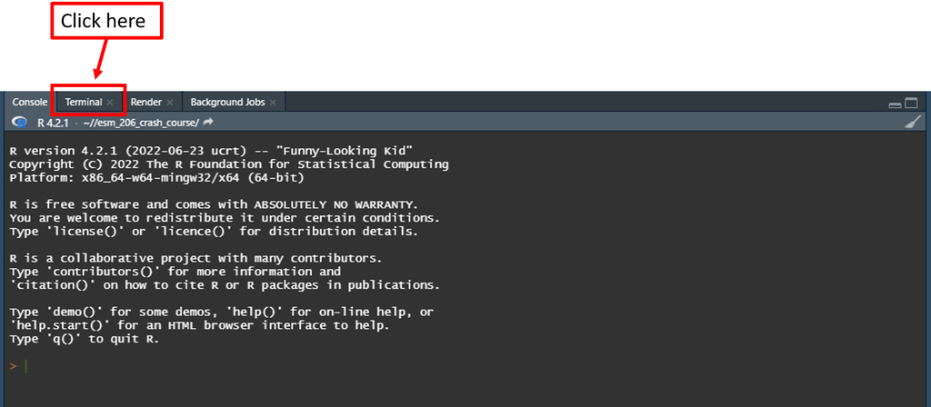

Let’s do a quick check to make sure we have Git install in the terminal. Run this code if you are on Windows.

```bash
where git
```

If you get `C:\Program Files\Git\cmd.git.exe` or `C:\Program Files\Git\pin\git.exe` congratulations your Git should be ready to connect to R. If you get errors, stop double check your installation of Git and come to office hours if it persists.

If on a Mac, run this instead in the Terminal

```bash
which git
```

Any errors stop and come see us in office hours. Otherwise continue to the next steps to introduce yourself to Git and connect it to GitHub.

Run the following commands in the Terminal (type in, then press Enter after each line), replacing the username and email (keep the quotation marks for each) with your username and email used for your GitHub account.

```bash
git config --global user.name "Jane Doe"

git config --global user.email "janedoe@example.com"
```

Next, in the Terminal run the following, carefully checking that the name and email returned match your GitHub information. If your username and email are returned, great! You’ve configured git successfully. If not, raise your hand and we’ll help you.

```bash
git config --list --global
```

Basically these steps tell Git please associate me with the github account connected to my email. Also when I make edits or touch things, store my changes as made by “username” so others can see who made the edits and when.

#### Store your Github personal access token (PAT)

Once you have git configured successfully in the steps above, install the usethis package in R by running the following in the RStudio Console: `install.packages("usethis")`

A lot of scary looking red text will show up while this is installing - don’t panic. If you get to the end and see something like below (with no error) it’s installed successfully.

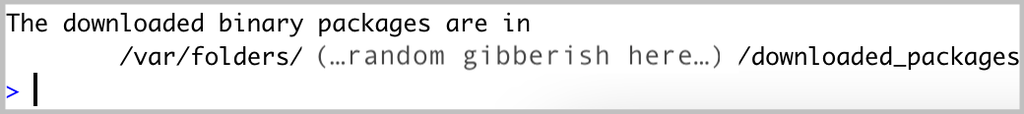

Run `usethis::create_github_token()` in the Rstudio Console.

This should automatically take you back to GitHub. Enter your GitHub password when prompted. You’ll be taken to a screen that looks like this, with the right options already auto-selected for you:

[figure not shown]

Change only the expiration date on the token. **Never have an unlimited expiration date!** These are secure tokens and how you access all your materials. If someone acquires your token somehow, they could corrupt your data or delete your work. Allowing them to expire keeps your work safe. It is easy to tell R about new tokens. I personally like the 90 days. At the beginning of every quarter it’s habit to just update my tokens.

Ignore the other stuff for now ([you can read about scopes here](https://docs.github.com/en/developers/apps/building-oauth-apps/scopes-for-oauth-apps)) and hit the green generate token button.

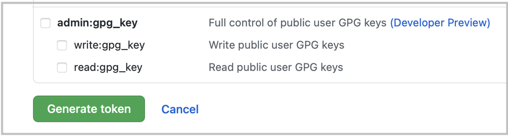

Copy the generated token to your clipboard

Back in Rstudio, in the Console run the following command `gitcreds::gitcreds_set()`

This will prompt you to paste the token you just copied from GitHub. Paste the PAT, press Enter. You should see something like this show up if all is well so far (you’ll have pasted your PAT where mine says “REDACTED”):

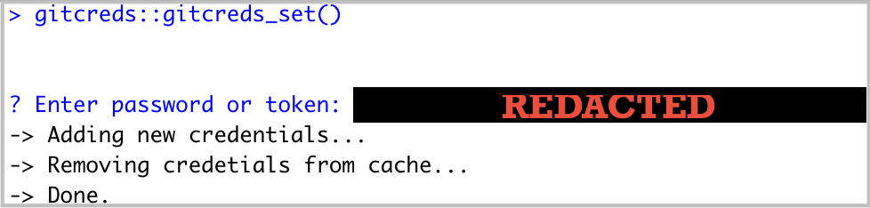

Next run `usethis::git_sitrep()` in the console. Does it return information about your connected GitHub account that looks something like below? Great! You’ve configured git and successfully stored your PAT.

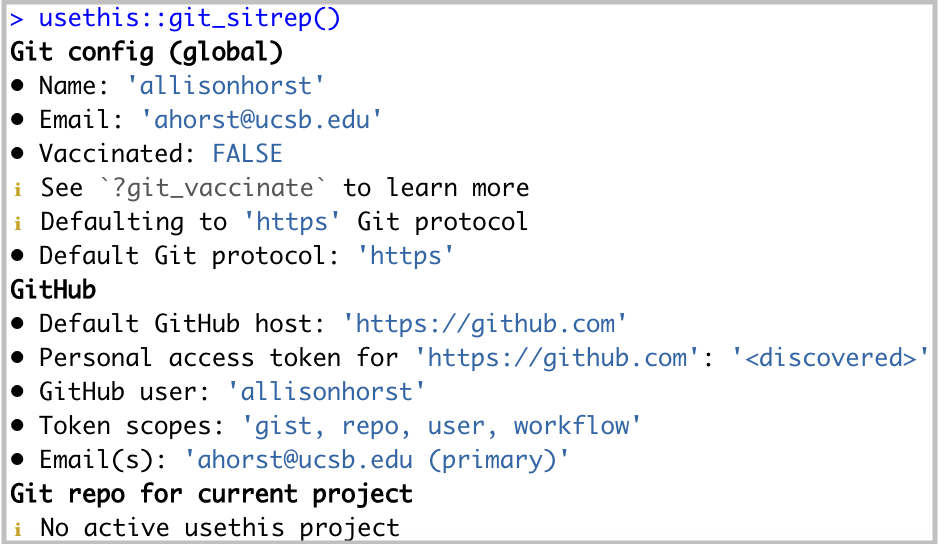

### Fork in a Repo

Now let’s see if Github is connected and everything worked! We’re going to “Fork” a repo. All forking means is we take a copy of somebody else’s repository. We don’t have access to change any files on the original repo, but we can make as many changes to our copy and version as we want. This is powerful tool for scientific communication and reproducibility. I can fork into a repo that an author published, check their data and methods, and verify that it indeed produces the results they articulated in their article. We’ll practice by loading in the repo where this crash course is stored.

1. [Follow this link to the esm-206-github-crash-course repo directory on Github](https://github.com/nggrimes/esm-206-github-crash-course)
2. Click the fork button on the top right. This brings a copy of the entire repo to your github account. After clicking the fork button it will open a new page to create a new fork. Leave everything has a default and click the big, green **create fork** at the bottom of the page.

[figure not shown]

```
a. An intermediate page will open asking if you want to change the repo name. Almost always you want to keep it the same as the original. Scroll to the bottom and click the **Green Button.**

b. It will now open a copy of your GitHub page. Check the left corner to see if it says "yourusername"/esm-206-github-crash-course
```

3. Once you fork it, now you have your own copy of that repo. But you still need to get it talking with RStudio so you can actually work with it. After forking, **click on the green ‘Code’ button**, then follow these instructions **carefully**:
   1. When you click ‘Code’, you should see a URL in the drop-down info. That URL is going to be the pathway that github and RStudio use to talk to each other. **Copy that link**.
   2. Open (or go back to) RStudio. Choose: File > New Project > Version Control > Git, which gets you to a screen like this:

[figure not shown]

   3. Paste the URL (that you copied from github when you pressed ‘Code’) into the **Repository URL:** section, then…
   4. If it didn’t already auto-populate, Press **TAB** to populate the **Project directory name:** section with the correct (matching) project named linked to the github repo, then…
   5. Choose where you want the version controlled project to live on your computer (probably within your ESM 206 folder somewhere…)
   6. Press **Create Project** (optional: select ‘Open in new session’ if you’re already working on stuff that you don’t want to close)
   7. What you’ve just created is a git-enabled project that contains all of the files contained in the forked repo, now sitting right in your working directory waiting for you to work with them.
4. Let’s make some changes to a document
   1. In RStudio, now click on the file ‘student_practice.Rmd’ under the src folder in the “Files” tab to open it
   2. Follow the instructions to manipulate the data and plot a graph. Make sure to save when done.
   3. Check your solutions with the student_practice_sol.Rmd
   4. Now that we have made changes locally we have to put it back on to the GitHub cloud
5. Go to the Git tab in RStudio (next to the Environment tab). Any updated files/projects will show up in the ‘Git’ tab in RStudio (probably just the .Rmd this time).
   1. To **stage** the updated file, select the empty box (under ‘Staged’) next to any file that appears there
   2. **Commit** the staged files by pressing the “Commit” button, then entering a brief commit message (e.g. “testing connection”), then press ‘Commit.’ No error = working. Close that window.
   3. After committing, press the upward green arrow to **Push** changes back to GitHub. No error = working. You may need to enter your github username/password to do this.

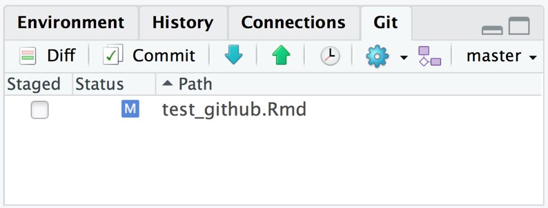

### Create Individual Repo

Now that your equipped with forking you can be your own content creator! Also you’ll be working on your own stuff and will create your own directories. The flow is very similar to forking, but I want you to point out a few key differences. Note: There are few ways to do this, but I like to start with github and work from there. If you already made a project locally in R and want to upload it to Github there are ways to do that as well.

1. Go to github to create a new repository. On your user profile select the repositories tab. The big green button on the top right will say new.
2. Give a unique name with no spaces or special characters. Typically a descriptive name separated by - is the most common structure.
3. Select public for now. If you have sensitive data or don’t feel ready to publish your results you can always start in private. **It is very difficult to go from public to private!**
4. Select add a README and add.gitignore with an R template
   1. README’s should always be included. They are formated in Markdown (Like this document!) and provide useful descriptions of what the repo does, how it is organized, and who made it.
   2. gitignores are special files that tell git and github which files we should ignore when uploading. For R projects, typically we want to avoid the actual rprojects files and any extra intermediate files like caches.
   3. Licenses are imporant once you start getting into package development and publishing results. This provides you basic copyright laws to protect your code. For the most part, we’ll never use licenes in this class, but maybe later on you’ll need to use it and [can read out it here](https://docs.github.com/en/repositories/managing-your-repositorys-settings-and-features/customizing-your-repository/licensing-a-repository)
   4. At the bottom select create repository. Here is an image with how setting up a new repository should look like. Use whatever name is appropriate for your work.

[figure not shown]

5. Edit your README to be descriptive. Then add a message to the commit changes box and finally select commit changes
6. Clone the repo by selecting the green code button at the repo home. Copy the link to your clipboard
7. Go to RStudio and open a new project.
8. Select Version Control and then Git.
9. Copy the url in the first space. Tell R where do you want to store the project locally in the second input line. **Keep the same folder name as the github repo!**
10. Make a new markdown document and plot something really quickly using the base palmer penguins data. Knit the document
    1. Attach palmerpenguins and tidyverse in a hidden code chunk (include=FALSE)
    2. Make a scatterplot of bodymass on the y-axis and flipper length on the x-axis with each species uniquely colored and shaped.
    3. Customize the ggplot into a beautiful image.
11. **Stage, Commit, and Push** your changes. Same steps from the fork repo tab.
12. Verify on github that your new markdown with changes is included

### Collaboration Demonstration

Renae and I will now walk through a quick demonstration of how collaboration can work with Github. She will be added as collaborator to a document we’ve been working on. I’ll make some edits then have her make edits. This is a very rudimentary introduction to show how useful it could be. To learn more about project management with multiple users take ESM 244 and we talk how to resolve common issues that pop up and the data management practices that limit problems.

If you want to practice with a partner I included a lab from last year that has you partner up with a classmate and work in the same document. Please refer to Lab 7 Part 1_git collab in the src folder and work through it with a partner sometime. Complete instructions are included. Renae and I will do an in class demonstration of the power of collaboration of GitHub. The general steps for setting up a collaboration within a repo are as follows:

1. Invite a collaborator through the settings tab in github.
2. New collaborator clones the repo to their local drive
3. Now they can make edits to the main branch and push and pull those changes.
4. As original owner, I need to pull changes by clicking the pull button (down arrow) before I make edits to update all files.

### Where we will go!

Future skills and abilities you’ll unlock with Github as you level up include:

- Using Branches to manage workflow across collaborators (ESM 244)
- Resolve merge conflicts (ESM 244)
- Handle pull requests (ESM 244)
- Load previous versions of code or data by searching through commit messages
- Discuss internal and public message boards to improve code
- Build websites to publish and showcase your work with the distill package (ESM 244)
- Host shiny apps to communicate your work dynamically and to broader audiences (ESM 244)
[^1]: Instructor for crash course
[^2]: Instructor for crash course
[^3]: Original creator of content